# Módulo 2: Densidad Visual y Cobertura Territorial

## Áreas de influencia

.

El análisis del entorno comercial no se limita a evaluar la separación lineal entre competidores, sino que requiere estudiar el espacio geográfico inmediato sobre el cual un negocio ejerce su capacidad de atracción de clientes. En este contexto, el desarrollo de **áreas de influencia** constituye una metodología fundamental para modelar la cobertura territorial de los establecimientos. Este enfoque permite trazar fronteras teóricas alrededor de cada coordenada, delimitando la superficie exacta donde se concentran los consumidores potenciales y donde el impacto operativo de la unidad económica es más intenso.

.

A nivel cartográfico, la creación de estas zonas se ejecuta mediante operaciones de geometría computacional de alta precisión. Específicamente, **se estructuran radios de proximidad caminable alrededor de los puntos utilizando la función `st_buffer`** de la librería `sf`. Este algoritmo matemático expande vectorialmente la coordenada del punto original de manera uniforme en todas direcciones, transformando un marcador bidimensional discreto en un polígono circular continuo cuyo radio representa una distancia métrica real previamente parametrizada por el analista.

.

Para fines de este estudio, se ha establecido un radio de búfer fijo de **500 metros**, una medida estandarizada internacionalmente en el urbanismo y el geomarketing para representar la “escala del peatón”. Esta distancia equivale aproximadamente a una caminata continua de entre 5 y 7 minutos a una velocidad promedio, considerada el umbral crítico que un consumidor urbano está dispuesto a recorrer a pie para realizar compras de primera necesidad o acceder a servicios gastronómicos locales antes de optar por un medio de transporte motorizado.

.

Al proyectar simultáneamente estos búferes sobre un tejido metropolitano denso, la herramienta cartográfica revela de inmediato las zonas de conflicto y competencia directa. Las áreas donde los círculos de 500 metros se intersectan o enciman evidencian una **superposición de áreas de captación**, lo que significa que múltiples comercios se disputan exactamente al mismo grupo de residentes o peatones. Cuanto mayor sea el solapamiento entre polígonos, más saturado estará el mercado local y mayor será el riesgo de canibalización comercial entre las unidades del sector.

.

Un requisito metodológico indispensable para la correcta ejecución de `st_buffer` es operar sobre un sistema de coordenadas proyectado que utilice el metro como unidad de medida, como la **Cónica Conforme de Lambert (CCL)**. Si la función se aplicara sobre coordenadas geográficas en grados decimales, el algoritmo interpretaría el parámetro numérico como grados angulares, desvirtuando por completo la escala del mapa. Al trabajar con la proyección CCL nativa, garantizamos que cada polígono generado tenga una superficie perfectamente circular y equivalente a un radio de 500 metros reales sobre el terreno.

.

Finalmente, el principal valor analítico de generar polígonos de amortiguamiento con `st_buffer` radica en su capacidad para servir como contenedores de información para el cruce de variables de terceros. Una vez delimitados los radios de 500 metros, es posible realizar intersecciones espaciales con capas del censo (como los datos por manzana del INEGI). Esto permite transicionar de un análisis puramente geométrico a uno socioeconómico, calculando con exactitud cuánta población total, cuántas viviendas o qué nivel de ingreso promedio habita dentro del área de influencia peatonal de cada negocio.

.

Con el propósito de evaluar las dinámicas de competencia y accesibilidad peatonal a nivel micro-urbano, **se delimitaron las áreas de influencia de 500 metros exclusivamente para la alcaldía Coyoacán**. Al restringir el análisis a esta escala local, el modelo conserva la individualidad de los polígonos generados por la función `st_buffer`.”

.

“Este enfoque metodológico detallado nos permite visualizar con precisión el solapamiento de mercado entre establecimientos vecinos dentro del tejido de la alcaldía. Al no disolver las geometrías, cada radio de caminabilidad mantiene asociados sus atributos originales, sentando las bases operativas para identificar los corredores con mayor saturación de clientes potenciales en el territorio.”

```r
unidades_comerciales <- st_read(
  here("BASES_DE_DATOS", "comercios_LCC.gpkg"),
  layer = "unidades_comerciales"
)
coyoacan <- unidades_comerciales %>%
  filter(cve_ent == "09" & cve_mun == "003")


municipios_zmvm <- st_read(
  here("BASES_DE_DATOS", "datos_espaciales.gpkg"),
  layer = "municipios_zmvm"
)
limite_coyoacan <- municipios_zmvm  %>%
  filter(CVEGEO == "09003")
```

```r
# Generar las áreas de influencia individuales de 500 metros
# Al aplicarlo directamente sobre el objeto 'sf', cada círculo hereda su fila correspondiente
coyoacan_buffers <- st_buffer(coyoacan, dist = 500)
```

```r
mapa_buffers_coyoacan <- ggplot() +
  # 1. Dibujar los buffers individuales con transparencia (alpha) para notar los encimes
  geom_sf(data = coyoacan_buffers, fill = "#2ecc71", color = "#27ae60", linewidth = 0.1, alpha = 0.3) +

  # 2. Dibujar los puntos originales al centro de cada círculo para referencia visual
  geom_sf(data = coyoacan, color = "#e74c3c", size = 0.5) +

  # Limitar la vista del mapa para encuadrar solo la zona de Coyoacán y no ver toda la ZMVM
  coord_sf(
    xlim = st_bbox(coyoacan_buffers)[c(1, 3)],
    ylim = st_bbox(coyoacan_buffers)[c(2, 4)],
    crs = st_crs(limite_coyoacan)
  ) +
  # 3. Dibujar el fondo del contorno de Coyoacán (Si tienes una capa de municipios/alcaldías)
    geom_sf(data = limite_coyoacan, fill = NA, color = "black", linewidth = 0.4) +

  # Títulos y diseño del mapa
  labs(
    title = "Radios de Proximidad Caminable (500 metros)",
    subtitle = "Áreas de influencia individuales y solapamientos en Coyoacán",
    x = "Longitud",
    y = "Latitud",
    caption = "Fuente: Elaboración propia utilizando st_buffer en R."
  ) +
  theme_minimal() +
  theme(
    plot.title = element_text(face = "bold", size = 14),
    plot.subtitle = element_text(size = 11, color = "gray30"),
    panel.grid = element_line(color = "gray92", linewidth = 0.2)
  )
```

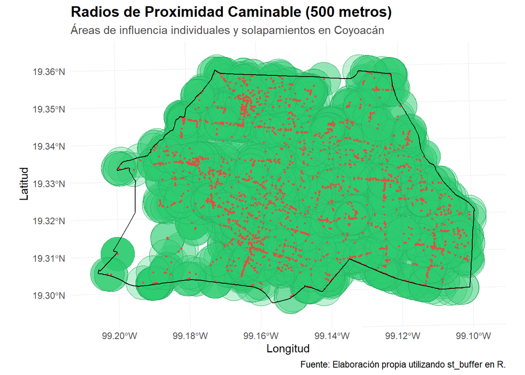

```r
print(mapa_buffers_coyoacan)
```

.

El mapa resultante de las áreas de influencia evidencia una **cobertura peatonal prácticamente total e ininterrumpida** a lo largo del territorio de Coyoacán. Al proyectar los radios de 500 metros desde cada establecimiento fijo, se observa que casi la totalidad de la traza urbana de la alcaldía queda integrada dentro de los perímetros de caminabilidad. Este hallazgo cartográfico demuestra que el tejido residencial de la demarcación goza de un acceso inmediato a pie a la oferta de servicios analizada, consolidando un entorno donde las distancias críticas de traslado peatonal están plenamente cubiertas.

.

A nivel de competencia, la visualización cartográfica expone un fenómeno masivo de **solapamiento de mercados (market overlapping)**. La densa aglomeración de polígonos verdes transparentes —que se intensifican y oscurecen en los ejes centrales y corredores principales de la alcaldía— revela que un mismo grupo de consumidores potenciales es disputado simultáneamente por decenas de establecimientos. Este patrón de vecindad extrema corrobora que la estrategia de localización predominante en Coyoacán se basa en capturar flujos en zonas de alta centralidad, asumiendo una fuerte presión de competencia espacial a cambio de proximidad física.

.

Morfológicamente, los radios de proximidad caminable de 500 metros dibujan la silueta de los principales ejes y arterias comerciales de Coyoacán, los cuales se alinean con los puntos rojos que señalan el núcleo de cada negocio. La continuidad espacial de la mancha verde confirma que no existen fragmentaciones significativas o ‘desiertos comerciales’ en la zona urbana consolidada de la alcaldía, lo que valida la viabilidad del comercio a escala peatonal y resalta el alto grado de madurez y densificación del mercado comercial en esta región metropolitana.

.

.

Borramos todo el entorno

```r
# Limpiar por completo el entorno de trabajo (borrar todos los objetos de la memoria)
rm(list = ls())
```

.

.

## Disolución geométrica

.

El análisis geoestadístico de las áreas de influencia individuales de 500 metros presenta una limitación geométrica inherente cuando se evalúan mercados altamente densificados. Debido a la colindancia extrema entre establecimientos, los polígonos circulares se superponen de manera masiva, generando zonas donde un mismo fragmento de suelo es contabilizado decenas de veces por diferentes unidades económicas. Si se calculara la superficie sumando el área de cada círculo de forma independiente, se incurriría en un error metodológico de doble conteo, arrojando una cifra artificial que superaría con creces la extensión territorial real de la región bajo estudio.

.

Para corregir esta distorsión y obtener métricas geográficas rigurosas, es indispensable aplicar un proceso de **disolución geométrica**. Esta técnica cartográfica consiste en fusionar entidades espaciales vecinas o superpuestas que comparten una lógica territorial común. Al disolver las fronteras interiores de los polígonos encimados, el analista transiciona de un modelo basado en capas discretas y competitivas hacia un modelo de superficie única, capaz de representar la huella geográfica real y consolidada del fenómeno económico analizado.

.

En el entorno de programación de R, esta unificación espacial se ejecuta de manera automatizada mediante la implementación de **la función `st_union`** de la librería `sf`. El algoritmo de este comando analiza las coordenadas vectoriales de todos los búferes y funde de manera matemática aquellas geometrías que intersectan sus perímetros. El resultado de esta operación es la creación de un objeto espacial de tipo multipolígono que suprime la redundancia cartográfica, optimizando la base de datos y aislando la verdadera extensión espacial continua que abarca la oferta comercial a escala de barrio.

.

La aplicación de `st_union` marca una división conceptual profunda dentro del desarrollo de la investigación. Mientras que los mapas anteriores —basados en círculos translúcidos y mapas de calor— tenían como objetivo evaluar la densidad de la competencia y el grado de saturación del mercado, la disolución geométrica está diseñada exclusivamente para medir la **cobertura y la accesibilidad ciudadana**. Este paso metodológico permite responder a la pregunta fundamental de qué tan extendido está el servicio en el territorio, independientemente de qué tan reñida sea la competencia interna entre los oferentes.

.

Una vez consolidada la superficie única mediante la disolución, el script permite calcular el **área neta de cobertura comercial expresada en metros cuadrados** (o kilómetros cuadrados). Gracias a que los datos operan nativamente bajo la proyección Cónica Conforme de Lambert (CCL), la cual conserva la proporcionalidad de las áreas sobre el plano, el cálculo numérico derivado carece de distorsiones cartográficas. Esta superficie real representa el espacio geográfico efectivo que se encuentra a una distancia caminable y accesible para cualquier peatón en la alcaldía.

.

Finalmente, la culminación de esta disolución geométrica permite estructurar el indicador de **cobertura porcentual del territorio**. Al dividir la superficie real unificada entre el área total de la demarcación, se obtiene una métrica estandarizada que resume la eficiencia de la distribución comercial a escala local. Este porcentaje actúa como el dato definitivo de cierre metodológico, ofreciendo una cifra sintética de alta utilidad para tomadores de decisiones, inversionistas o planificadores orientados a evaluar el nivel de madurez, conectividad y consolidación urbana del municipio piloto.

.

Carguemos nuestros datos.

```r
unidades_comerciales <- st_read(
  here("BASES_DE_DATOS", "comercios_LCC.gpkg"),
  layer = "unidades_comerciales"
)
coyoacan <- unidades_comerciales %>%
  filter(cve_ent == "09" & cve_mun == "003")


municipios_zmvm <- st_read(
  here("BASES_DE_DATOS", "datos_espaciales.gpkg"),
  layer = "municipios_zmvm"
)
limite_coyoacan <- municipios_zmvm  %>%
  filter(CVEGEO == "09003")
```

```r
# Generar las áreas de influencia individuales de 500 metros
# Al aplicarlo directamente sobre el objeto 'sf', cada círculo hereda su fila correspondiente
coyoacan_buffers <- st_buffer(coyoacan, dist = 500)
```

```r
# DISOLUCIÓN GEOMÉTRICA (FUSIONAR LOS BÚFERES)

# Unificar todos los círculos de 500m de Coyoacán en una sola mancha continua
cobertura_disuelta <- st_union(coyoacan_buffers)

# Recortar la mancha resultante usando el límite exacto de la alcaldía
# Esto elimina los desbordamientos fuera de las fronteras de Coyoacán
cobertura_coyoacan <- st_intersection(cobertura_disuelta, st_geometry(limite_coyoacan))
```

```r
# CÁLCULO DE SUPERFICIES REALES (EN KILÓMETROS CUADRADOS)

# Calcular el área total de la Alcaldía Coyoacán
area_total_m2 <- st_area(limite_coyoacan)
area_total_km2 <- as.numeric(area_total_m2) / 1000000

# Calcular el área real cubierta por el comercio (sin doble conteo)
area_cubierta_m2 <- st_area(cobertura_coyoacan)
area_cubierta_km2 <- as.numeric(area_cubierta_m2) / 1000000
```

```r
# GENERACIÓN DE INDICADORES PORCENTUALES

# Calcular el porcentaje de territorio cubierto
porcentaje_cobertura <- (area_cubierta_km2 / area_total_km2) * 100

# Calcular el porcentaje de desierto comercial (vacíos de abasto)
porcentaje_desierto <- 100 - porcentaje_cobertura
```

```r
# DESPLEGAR RESULTADOS EN CONSOLA

cat("====================================================\n")
cat("       INDICADORES DE COBERTURA GEOMÉTRICA          \n")
```

```
       INDICADORES DE COBERTURA GEOMÉTRICA
```

```r
cat("====================================================\n")
cat(paste("Superficie Total de Coyoacán:     ", round(area_total_km2, 2), "km²\n"))
```

```
Superficie Total de Coyoacán:      53.62 km²
```

```r
cat(paste("Superficie Real Comercial:         ", round(area_cubierta_km2, 2), "km²\n"))
```

```
Superficie Real Comercial:          52.39 km²
```

```r
cat(paste("Porcentaje de Cobertura Peatonal:  ", round(porcentaje_cobertura, 2), "%\n"))
```

```
Porcentaje de Cobertura Peatonal:   97.7 %
```

```r
cat(paste("Porcentaje de Desierto Comercial:  ", round(porcentaje_desierto, 2), "%\n"))
```

```
Porcentaje de Desierto Comercial:   2.3 %
```

```r
cat("====================================================\n")
```

.

.

El cálculo de la huella comercial sin duplicidades revela la madurez del mercado inmobiliario y comercial en la demarcación. Con un **97.7% del suelo cubierto por los radios de influencia de 500 metros**, Coyoacán se consolida como un espacio urbano densamente servido, donde prácticamente no existen nichos geográficos desatendidos. El análisis geométrico demuestra que la expansión de nuevos comercios fijos ya no responde a la necesidad de colonizar áreas desprovistas de servicios, sino a una estrategia de competencia interna y captura de flujos dentro de un mercado que ya opera en condiciones de saturación espacial.

.

El proceso de unificación espacial mediante `st_union` valida la hipótesis de una cobertura comercial generalizada. El indicador sintético arroja que **el 97.7% de la demarcación se encuentra plenamente integrada bajo rangos de caminabilidad peatonal**, dejando únicamente un **2.3% (equivalente a 1.23 km²)** como desierto comercial. Estos resultados cuantitativos demuestran la eficiencia de la distribución espacial de los establecimientos fijos y cierran el diagnóstico metodológico con una métrica precisa del nivel de inclusión y conectividad comercial en la alcaldía de estudio.

.

.

## Brechas comerciales

.

La validación metodológica completada con éxito en la alcaldía Coyoacán constituye la línea base operativa del estudio, pero un diagnóstico metropolitano integral exige trascender las fronteras de un único caso de éxito local. Con el objetivo de profundizar en la comprensión de las asimetrías urbanas y comerciales de la región, **se procederá a aplicar la misma secuencia de algoritmos geoespaciales en un segundo municipio de estudio (Zumpango)**. Este análisis comparativo resulta fundamental para someter el modelo de proximidad a diferentes condiciones de densidad poblacional, conectividad vial e infraestructura socioeconómica.

.

Mientras que el caso piloto reflejó las dinámicas propias de una centralidad urbana madura y densamente servida, la incorporación de una nueva demarcación —con características socio-espaciales contrastantes o de carácter periférico— permitirá poner a prueba la variabilidad de las métricas. Este ejercicio metodológico busca confrontar la alta consolidación habitacional con entornos donde la traza urbana aún se encuentra en fases de expansión, lo que alterará de manera previsible la geometría de las áreas de influencia y los radios de caminabilidad peatonal de 500 metros.

.

Este paso consolida la replicabilidad y estandarización del flujo de trabajo diseñado en R. Al automatizar la limpieza de geometrías nulas, la extracción de coordenadas bajo la proyección Cónica Conforme de Lambert (CCL) y el cálculo matemático con la función `st_buffer`, se garantiza que los indicadores de este segundo municipio sean perfectamente homogéneos con los ya obtenidos. Esta estricta consistencia en la sintaxis de programación elimina los sesgos metodológicos y asegura que las diferencias observadas correspondan de manera fiel a las dinámicas del territorio y no a discrepancias en el procesamiento de los datos.

.

Carguemos los datos

```r
unidades_comerciales <- st_read(
  here("BASES_DE_DATOS", "comercios_LCC.gpkg"),
  layer = "unidades_comerciales"
)
zumpango <- unidades_comerciales %>%
  filter(cve_ent == "15" & cve_mun == "120")


municipios_zmvm <- st_read(
  here("BASES_DE_DATOS", "datos_espaciales.gpkg"),
  layer = "municipios_zmvm"
)
limite_zumpango <- municipios_zmvm  %>%
  filter(CVEGEO == "15120")
```

```r
# ÁREAS DE INFLUENCIA

# Crear los búferes individuales de 500 metros
zumpango_buffers <- st_buffer(zumpango, dist = 500)

# Unificar (disolver) todos los polígonos para evitar el doble conteo de área
cobertura_disuelta_zumpango <- st_union(zumpango_buffers)

# Recortar la cobertura resultante estrictamente dentro del borde de Zumpango
cobertura_real_zumpango <- st_intersection(cobertura_disuelta_zumpango, st_geometry(limite_zumpango))
```

```r
# EXTRACCIÓN DE BRECHAS (DESIERTOS ALIMENTARIOS)

# Restar la mancha comercial al polígono base de Zumpango para aislar los huecos
desiertos_zumpango <- st_difference(st_geometry(limite_zumpango), cobertura_real_zumpango)
```

```r
# CÁLCULO DE SUPERFICIES Y RATIOS PORCENTUALES


# Superficie total del municipio (de metros cuadrados a kilómetros cuadrados)
area_tot_m2 <- st_area(limite_zumpango)
area_tot_km2 <- as.numeric(area_tot_m2) / 1000000

# Superficie real con cobertura comercial peatonal
area_cob_m2 <- st_area(cobertura_real_zumpango)
area_cob_km2 <- as.numeric(area_cob_m2) / 1000000

# Porcentajes finales
pct_cobertura <- (area_cob_km2 / area_tot_km2) * 100
pct_desierto <- 100 - pct_cobertura
```

```r
# DESPLEGAR INDICADORES COMPARATIVOS EN CONSOLA
# ==============================================================================
cat("====================================================\n")
cat("      INDICADORES DE COBERTURA GEOMÉTRICA: ZUMPANGO \n")
```

```
      INDICADORES DE COBERTURA GEOMÉTRICA: ZUMPANGO
```

```r
cat("====================================================\n")
cat(paste("Cantidad de Comercios:       ", nrow(zumpango), "\n"))
```

```
Cantidad de Comercios:        842
```

```r
cat(paste("Superficie Total del Municipio:    ", round(area_tot_km2, 2), "km²\n"))
```

```
Superficie Total del Municipio:     222.13 km²
```

```r
cat(paste("Superficie Real Comercial:         ", round(area_cob_km2, 2), "km²\n"))
```

```
Superficie Real Comercial:          66.52 km²
```

```r
cat(paste("Porcentaje de Cobertura Peatonal:  ", round(pct_cobertura, 2), "%\n"))
```

```
Porcentaje de Cobertura Peatonal:   29.94 %
```

```r
cat(paste("Porcentaje de Desierto Comercial:  ", round(pct_desierto, 2), "%\n"))
```

```
Porcentaje de Desierto Comercial:   70.06 %
```

```r
cat("====================================================\n")
```

Los indicadores geográficos de Zumpango revelan un contraste estructural profundo respecto a las dinámicas observadas en la prueba piloto de Coyoacán, evidenciando las severas asimetrías que fracturan la Zona Metropolitana. Con una extensión territorial significativamente mayor (**222.13 km²**) pero con apenas **842 comercios**, la superficie real de cobertura comercial caminable se restringe a **66.52 km²**. Esto significa que **el porcentaje de cobertura peatonal cae drásticamente al 29.94%**, consolidando un modelo de dispersión donde **el 70.06% del municipio constituye un desierto comercial**. Esta preocupante brecha confirma que la periferia norte opera bajo lógicas de baja conectividad y desabasto, donde la escala del peatón es insuficiente y la población se ve obligada a depender del transporte motorizado para satisfacer sus necesidades básicas.

.

El análisis de la huella comercial en Zumpango expone de forma nítida la desconexión entre el crecimiento habitacional y la infraestructura de servicios en las periferias metropolitanas. A diferencia del tejido consolidado y continuo de las centralidades urbanas, los 842 comercios del municipio se agrupan en núcleos aislados (como el centro histórico local o fraccionamientos habitacionales específicos), dejando inmensos vacíos territoriales sin cobertura. El hecho de que siete de cada diez kilómetros cuadrados (**70.06%**) estén catalogados como desiertos comerciales refleja una morfología urbana fragmentada, donde los desarrollos de vivienda masiva muchas veces se construyen desprovistos de un tejido comercial local accesible a pie.

.

```r
mapa_brechas_zumpango <- ggplot() +
  # Fondo: El municipio completo
  geom_sf(data = limite_zumpango, fill = "gray93", color = "gray60", linewidth = 0.5) +

  # Cobertura caminable en verde tenue
  geom_sf(data = cobertura_real_zumpango, fill = "#d4efdf", color = NA, alpha = 0.6) +

  # Resaltar brechas/desiertos alimentarios en rojo brillante
  geom_sf(data = desiertos_zumpango, fill = "#e74c3c", color = "#c0392b", linewidth = 0.3) +

  labs(
    title = "Detección Gráfica de Brechas Comerciales: Zumpango",
    subtitle = "Zonas rojas representan el territorio fuera del rango caminable (500m)",
    x = "Longitud", y = "Latitud",
    caption = "Fuente: Análisis de brechas espaciales en R."
  ) +
  coord_sf(crs = st_crs(limite_zumpango)) +
  theme_minimal() +
  theme(
    plot.title = element_text(face = "bold", size = 13),
    plot.subtitle = element_text(size = 10, color = "gray30"),
    panel.grid = element_line(color = "gray90", linewidth = 0.2)
  )
```

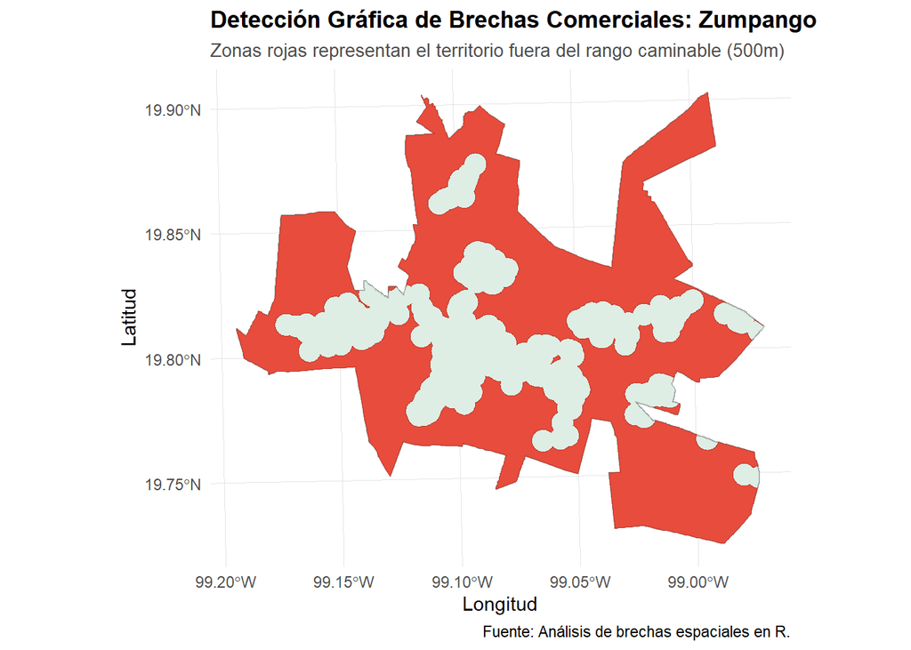

```r
print(mapa_brechas_zumpango)
```

El mapa visualiza con precisión la magnitud de los **desiertos comerciales** en la periferia norte de la metrópoli. La masiva presencia del color rojo —que domina las franjas norte, sur y el extremo oriente del municipio— demuestra que la escala peatonal es inviable para la mayor parte del suelo de Zumpango. Al restar la huella comercial del mapa base, queda en evidencia que los residentes de estas extensas zonas rojas se encuentran desprovistos de comercios fijos a distancias caminables (500 metros), lo que perpetúa una dependencia estructural hacia el transporte motorizado o colectivo y acentúa las condiciones de vulnerabilidad alimentaria y de servicios en la periferia.

.

.

Borramos todo el entorno

```r
# Limpiar por completo el entorno de trabajo (borrar todos los objetos de la memoria)
rm(list = ls())
```

.

.

Muchas gracias por completar el segundo modulo.